# cnv-Freq_task

Ann-Léonie Beck

2023-09-27

# Tumor information: Lung Squamous Cell Carcinoma

The NCIt code is C3493 Lung Squamous Cell Carcinoma is a type of non-small cell lung cancer. It affects the central part of the lung or the main airway (left or right bronchus). There exist three subtypes of Lung Squamous Cell Carcinoma, namely: Keratinizing, Non-keratinizing, basaloid.

Risk factors include: smoking, age, family history, exposure to second-hand smoke, mineral and metal particels, or asbestos. Smoking is the main risk factor associated with Lung Squamous Cell Carcinoma. 30% of non-small cell lung cancer are reported to be Lung Squamous Cell Carcinoma. Squamous cells are thin and flat, among other organs they coat the airways of the human body. The origin of Lung Squamous Cell Carcinoma is a transformation of the squamous cells of the airways

[Squamou cell Lung cancer](https://www.ncbi.nlm.nih.gov/books/NBK564510/)

# Access the CNV frequency data

## Load library

```r
library(pgxRpi)
```

## Access data

```r
freq <- pgxLoader(type='frequency', output = 'pgxfreq', filters = "NCIT:C3493")
```

The metadata information is

```r
freq$meta
```

```
##         code                        label sample_count
## 1 NCIT:C3493 Lung Squamous Cell Carcinoma         1938
## 2      total                                      1938
```

The data looks like this

```r
freq$data$`NCIT:C3493`[c(1:3),]
```

```
##      filters reference_name   start     end gain_frequency loss_frequency no
## 1 NCIT:C3493              1       0  400000          5.315          5.418  1
## 2 NCIT:C3493              1  400000 1400000          8.978         15.738  2
## 3 NCIT:C3493              1 1400000 2400000          6.553         16.202  3
```

# Visualization

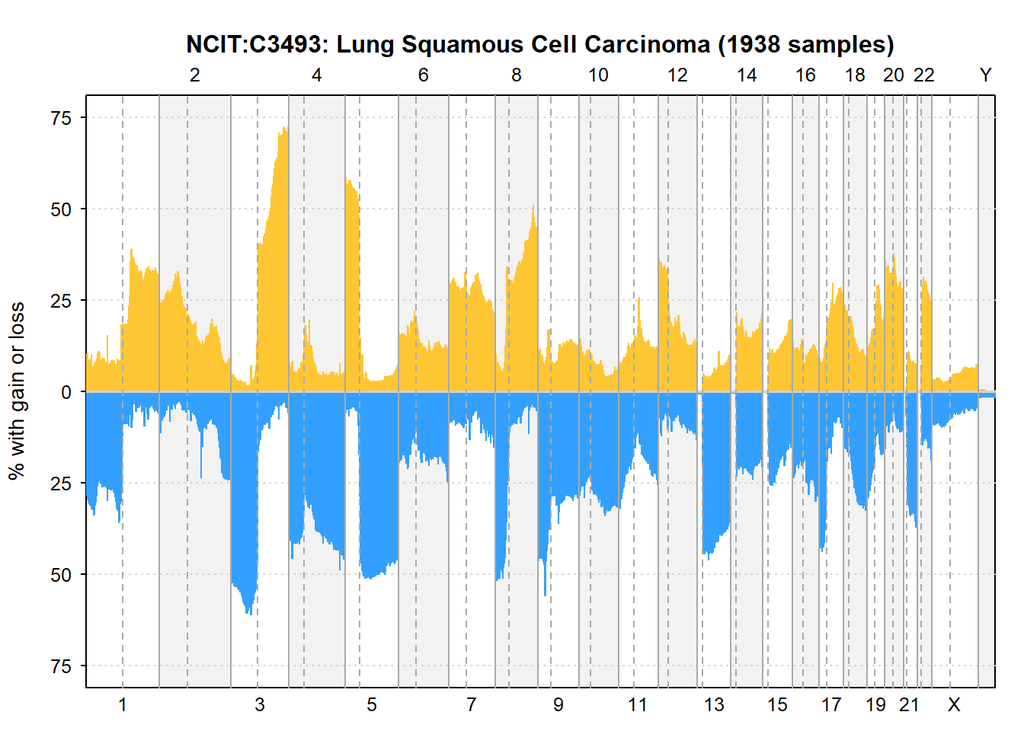

```r
pgxFreqplot(freq)
```

## Chromosom specific plot

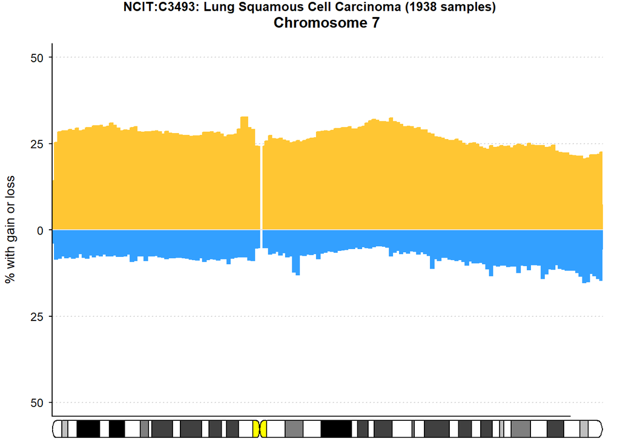

```r
pgxFreqplot(freq, chrom = 7)
```

# Analysis

According to the plot, there are frequent duplication on chromosom 1q, 2p, 3q, 5p, 7p, 7q, 8q, 12p, 17q, 19q, 20p, 20q, 22q and frequent deletion on chromosome 1p, 3p, 4p, 4q, 5q, 8p, 9p, 9q, 10p, 10q, 11p, 13q, 16q, 17p, 18q, 19p, 21q with 25% as a cut-off.

One [study](https://doi.org/10.1002/gcc.22460) detected frequent gains of 1q, 2p, 3q, 5p, 7p, 7q, 8q, 12p, 17q, 19q, 20p, 20q, 22p, 22q and frequent deletion on chromosome 3p, 4p, 4q, 5q, 8p, 9p, 10q, 11p, 13p, 13q, 17p, 21p, 21q.

There are overlaps: 1q, 2p, 3q, 5p, 7p, 7q, 8q, 12p, 17q, 19q, 20p, 20q, 22q for duplication; 3p, 4p, 4q, 5q, 8p, 9p, 10q, 11p, 13q, 17p, 21q for deletion.

Possible differences could be explained by the fact that it was hard to define a cut-off value for the study.